# Homework #7

Due 11:59 pm EST, Friday April 22nd, 2022.

Email your solutions (both .ipnb and .html files) to: compscbio@gmail.com.

### Background:

There is extensive, dyanmic cell-cell communication during development. In the Cell fate engineering (CFE) world, we frequently ignore this and make the convenient assumption that our manipulation of signaling pathways via exposure to exogenous ligands and inhibitors will drown out such cell-cell communications that impact differentiation. In this homework, you will infer the cell-cell communications that are occuring during ... wait for it ... directed differentiation of mESCs. You will use a superset of the data from HW2, which was a timecourse of directed differentation. Recall that this data also included some residual fibroblasts. Unfortunately, there are not many tools for performing CCC available in Python.

### The data and Ligand receptor database.

1. [mESC differention day0-day4](https://compstemcellbio.s3.amazonaws.com/2022/homework/07/adHW7_040822.h5ad) This is the raw counts data. It is a superset of the data from HW2, which was actually published in [Emily Su's Epoch paper](https://pubmed.ncbi.nlm.nih.gov/35090587/). There are other lineages beyond mesoderm. We have also included leiden labels, and timepoints, and treatments. The cluster labels and timepoints are all that you will need.
2. [Mouse ligand-receptor pairs as defined by CellTalkDB](https://compstemcellbio.s3.amazonaws.com/2022/homework/07/mouse_lr_pair.txt). The first three columns are most useful: l-r pair, ligand gene name, receptor gene name. Feel free to explore [CellTalkDB](http://tcm.zju.edu.cn/celltalkdb/index.php) more.

### Your mission:

1.) Write a function in Python that will quantify potential cell-cell interactions based on expression of ligands and cognate receptors. The input will be the expression data with cell labels (you can use the leiden clusters that we provide), as well as the ligand receptor database. The output should quantify the likely interaction between each pair of clusters for each ligand-receptor pair. Feel free to implement any of the methods that we discussed in class, or devise your own method. Please see the review paper that we posted to Blackboard for more comprehensive discussion of the topic.

2.) Apply your method to cells from each timepoint of the mESC differentiation data.

3.) Devise an efficient way to visualize the most prominent cell-cell interactions that characterize this data and use it.

```python
# import
import pandas as pd
import matplotlib.pyplot as plt
import seaborn as sns
import scanpy as sc
import scipy as sp
import numpy as np
import warnings

warnings.filterwarnings('ignore')
```

```python
# read in the adata
adata = sc.read_h5ad('adHW7_040822.h5ad')
adata
```

```
AnnData object with n_obs × n_vars = 7255 × 31065
    obs: 'timepoint', 'treatment', 'condition', 'n_genes_by_counts', 'total_counts', 'total_counts_ribo', 'pct_counts_ribo', 'total_counts_mt', 'pct_counts_mt', 'leiden'
    var: 'mt', 'ribo', 'n_cells_by_counts', 'mean_counts', 'pct_dropout_by_counts', 'total_counts'
    layers: 'matrix'
```

```python
adata.obs['leiden'].value_counts()
```

```
0     1394
1     1026
2      991
3      852
4      708
5      541
6      515
7      362
8      286
9      280
10     229
11      47
12      24
Name: leiden, dtype: int64
```

```python
# read in ligand receptor db
ligand_receptor_db = pd.read_csv('mouse_lr_pair.txt', sep='\t')
```

```python
ligand_receptor_db
```

|  | lr_pair | ligand_gene_symbol | receptor_gene_symbol | ligand_gene_id | receptor_gene_id | ligand_ensembl_protein_id | receptor_ensembl_protein_id | ligand_ensembl_gene_id | receptor_ensembl_gene_id | evidence |
| --- | --- | --- | --- | --- | --- | --- | --- | --- | --- | --- |
| 0 | Wnt3_Fzd6 | Wnt3 | Fzd6 | 22415 | 14368 | ENSMUSP00000000127 | ENSMUSP00000022906 | ENSMUSG00000000125 | ENSMUSG00000022297 | 19901330 |
| 1 | Wnt3_Egfr | Wnt3 | Egfr | 22415 | 13649 | ENSMUSP00000000127 | ENSMUSP00000020329 | ENSMUSG00000000125 | ENSMUSG00000020122 | 17374561 |
| 2 | Wnt3_Fzd2 | Wnt3 | Fzd2 | 22415 | 57265 | ENSMUSP00000000127 | ENSMUSP00000091463 | ENSMUSG00000000125 | ENSMUSG00000050288 | 31907106 |
| 3 | Wnt3_Lrp5 | Wnt3 | Lrp5 | 22415 | 16973 | ENSMUSP00000000127 | ENSMUSP00000025856 | ENSMUSG00000000125 | ENSMUSG00000024913 | 11719191 |
| 4 | Wnt3_Fzd1 | Wnt3 | Fzd1 | 22415 | 14362 | ENSMUSP00000000127 | ENSMUSP00000058629 | ENSMUSG00000000125 | ENSMUSG00000044674 | 20667980 |
| ... | ... | ... | ... | ... | ... | ... | ... | ... | ... | ... |
| 2028 | Nrg4_Erbb4 | Nrg4 | Erbb4 | 83961 | 13869 | ENSMUSP00000130929 | ENSMUSP00000114123 | ENSMUSG00000032311 | ENSMUSG00000062209 | 17432114 |
| 2029 | Adamts3_Ccbe1 | Adamts3 | Ccbe1 | 330119 | 320924 | ENSMUSP00000132219 | ENSMUSP00000117636 | ENSMUSG00000043635 | ENSMUSG00000046318 | 27159393 |
| 2030 | Bmp6_Acvr2b | Bmp6 | Acvr2b | 12161 | 11481 | ENSMUSP00000126999 | ENSMUSP00000126108 | ENSMUSG00000039004 | ENSMUSG00000061393 | 23433114 |
| 2031 | Pdgfd_Pdgfra | Pdgfd | Pdgfra | 71785 | 18595 | ENSMUSP00000128388 | ENSMUSP00000127173 | ENSMUSG00000032006 | ENSMUSG00000029231 | 29410092 |
| 2032 | Apoe_Vldlr | Apoe | Vldlr | 11816 | 22359 | ENSMUSP00000133302 | ENSMUSP00000127329 | ENSMUSG00000002985 | ENSMUSG00000024924 | 12870663,11421580 |

2033 rows × 10 columns

```python
adata.X
```

```
<7255x31065 sparse matrix of type '<class 'numpy.float32'>'
	with 31852634 stored elements in Compressed Sparse Row format>
```

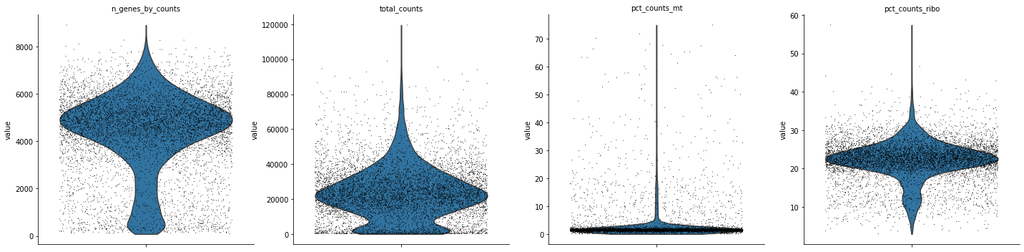

```python
axs = sc.pl.violin(adata, ['n_genes_by_counts', 'total_counts', 'pct_counts_mt', 'pct_counts_ribo'],jitter=0.4, multi_panel=True)
```

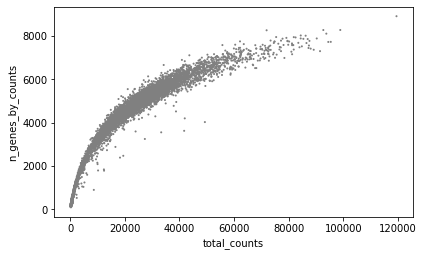

```python
sc.pl.scatter(adata, x='total_counts', y='n_genes_by_counts')
```

```python
adata.n_obs
```

```
7255
```

```python
# preprocess since we have raw data, doublets, ribo, mt, bad genes, rare genes, norm
def preProcess(adata):
    thresh = np.percentile(adata.obs['total_counts'],95)
    adata = adata[adata.obs['total_counts'] < thresh, :]
    adata = adata[adata.obs['pct_counts_mt'] < 10, :]
    adata = adata[adata.obs['pct_counts_ribo'] < 50, :]

    gThresh = 5

    sc.pp.filter_genes(adata, min_cells=gThresh)

    mito_genes = adata.var_names.str.startswith('mt-')
    ribo_genes = adata.var_names.str.startswith(("Rpl","Rps"))
    malat_gene = adata.var_names.str.startswith("Malat1")

    remove = np.add(mito_genes, ribo_genes)
    remove = np.add(remove, malat_gene)


    keep = np.invert(remove)
    adata = adata[:,keep].copy()

    sc.pp.normalize_total(adata, target_sum=1e4)
    # sc.pp.log1p(adata)
    # sc.pp.scale(adata, max_value=10)

    return adata
```

```python
adata = preProcess(adata)
```

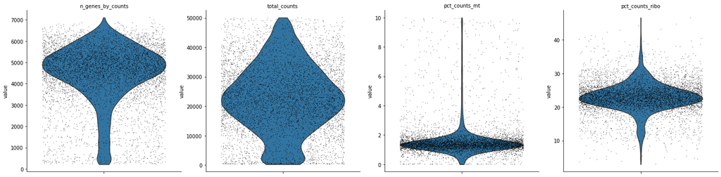

```python
axs = sc.pl.violin(adata, ['n_genes_by_counts', 'total_counts', 'pct_counts_mt', 'pct_counts_ribo'],jitter=0.4, multi_panel=True)
```

```python
adata.obs['leiden'].value_counts()
```

```
0     1318
1      981
2      906
3      838
5      525
6      511
4      303
8      271
9      258
7      249
10     224
11      47
12      23
Name: leiden, dtype: int64
```

```python
adata
```

```
AnnData object with n_obs × n_vars = 6454 × 18015
    obs: 'timepoint', 'treatment', 'condition', 'n_genes_by_counts', 'total_counts', 'total_counts_ribo', 'pct_counts_ribo', 'total_counts_mt', 'pct_counts_mt', 'leiden'
    var: 'mt', 'ribo', 'n_cells_by_counts', 'mean_counts', 'pct_dropout_by_counts', 'total_counts', 'n_cells'
    layers: 'matrix'
```

```python
# # potential tool to try
# run NATMI/DiffEdges
```

```python
ligand_receptor_db['ligand_gene_symbol'].value_counts()
```

```
App        26
Fgf2       18
Adam10     16
Thbs1      16
Wnt5a      15
           ..
Srpx2       1
Scgb1a1     1
Mmp12       1
Apom        1
Adamts3     1
Name: ligand_gene_symbol, Length: 651, dtype: int64
```

```python
ligand_receptor_db['receptor_gene_symbol'].value_counts()
```

```
Itgb1     50
Lrp1      29
Itgav     29
Egfr      27
Lrp6      27
          ..
Dchs1      1
Cadm1      1
Agtr1b     1
Agtr2      1
Tmem67     1
Name: receptor_gene_symbol, Length: 588, dtype: int64
```

```python
# store mean expression of each gene for each cluster in res
# code help for res: https://scanpy.discourse.group/t/how-to-calculate-the-average-gene-expression-within-each-cluster/126
def quantifyInteraction(anndata, ligand_receptor_db):
    '''
    This function calc's lr interaction scores for all cluster pairs for all lr pairs in a given lr db.
    Returns a dictionary with keys = ligand cluster as a string and values = df
    DF with idx = other clusters as int's
    DF with cols = lr pairs
    LR score = LxR
    L = mean expression of L in the cluster
    R = mean expressing of R in the cluster
    '''
    adata = anndata

    # store mean expression of each gene for each cluster in res
    res = pd.DataFrame(columns=adata.var_names, index=adata.obs['leiden'].cat.categories)

    for clust in adata.obs.leiden.cat.categories:
        res.loc[clust] = adata[adata.obs['leiden'].isin([clust]),:].X.mean(0)

    # dictionary with keys = cluster, values = df with columns = other clusters / rows = ligand/receptor pairs
    interaction_dict = {}

    # check to see which ligs and receps are in our data, remove the pairs froms the db that are not avail in our data
    # genes not in our data
    missing_lgenes = list(set(ligand_receptor_db['ligand_gene_symbol']) - set(res.columns))
    missing_rgenes = list(set(ligand_receptor_db['receptor_gene_symbol']) - set(res.columns))

    # drop the rows in the db that contain either one of these
    ligand_receptor_db = ligand_receptor_db[~ligand_receptor_db['ligand_gene_symbol'].isin(missing_lgenes)]
    ligand_receptor_db = ligand_receptor_db[~ligand_receptor_db['receptor_gene_symbol'].isin(missing_rgenes)]

    for cluster in adata.obs['leiden'].unique():

        # get all clusters as nums
        other_clusters = list(map(int, adata.obs['leiden'].unique()))

        # remove the current cluster
        other_clusters.remove(int(cluster))

        # sort
        other_clusters.sort()

        # set other clusters to idx's
        interaction_dict[cluster] = pd.DataFrame(index=other_clusters)

        # iterate through lr pairs
        for (lr_pair, l, r) in zip(ligand_receptor_db['lr_pair'],
                                   ligand_receptor_db['ligand_gene_symbol'],
                                   ligand_receptor_db['receptor_gene_symbol']):

            # store lr values, keys = other clusters
            this_lr_pair = {}

            # iterate through the other clusters
            for other_clus in other_clusters:

                lr_val = res.loc[cluster, l]*res.loc[str(other_clus), r]
                this_lr_pair[other_clus] = lr_val

            # add column (colnames = lr pairs, row names = other clusters)
            interaction_dict[cluster][lr_pair] = this_lr_pair.values()

    return interaction_dict
```

```python
# # used for testing
# # interaction_dicttionary with keys = cluster, values = df with columns = other clusters / rows = ligand/receptor pairs
# interaction_dict = {}

# # check to see which ligs and receps are in our data, remove the pairs froms the db that are not avail in our data
# # genes not in our data
# missing_lgenes = list(set(ligand_receptor_db['ligand_gene_symbol']) - set(res.columns))
# missing_rgenes = list(set(ligand_receptor_db['receptor_gene_symbol']) - set(res.columns))

# # drop the rows in the db that contain either one of these
# ligand_receptor_db = ligand_receptor_db[~ligand_receptor_db['ligand_gene_symbol'].isin(missing_lgenes)]
# ligand_receptor_db = ligand_receptor_db[~ligand_receptor_db['receptor_gene_symbol'].isin(missing_rgenes)]

# for cluster in adata.obs['leiden'].unique():

#     # get all clusters as nums
#     other_clusters = list(range(0, max(list(map(int, adata.obs['leiden'].unique())))+1))

#     # remove the current cluster
#     other_clusters.remove(int(cluster))

#     # set other clusters to idx's
#     interaction_dict[cluster] = pd.DataFrame(index=other_clusters)

#     for (lr_pair, l, r) in zip(ligand_receptor_db['lr_pair'], ligand_receptor_db['ligand_gene_symbol'], ligand_receptor_db['receptor_gene_symbol']):
#         this_lr_pair = {}
#         for other_clus in other_clusters:
#             lr_val = res[l].iloc[int(cluster)]*res[r].iloc[other_clus]
#             this_lr_pair[other_clus] = lr_val

#         # add column (colnames = lr pairs, row names = other clusters)
#         interaction_dict[cluster][lr_pair] = this_lr_pair.values()
```

```python
# we now have a dictionary with clusters as keys and values = a df
# the df's contain idx = other columns and rows = lr pairs
# each value in the df is lxr expression values, the higher this number the greater the interaction
interaction_dict = quantifyInteraction(adata, ligand_receptor_db)
```

```python
interaction_dict['10']
```

|  | Wnt3_Fzd6 | Wnt3_Egfr | Wnt3_Fzd2 | Wnt3_Lrp5 | Wnt3_Fzd1 | Wnt3_Fzd3 | Wnt3_Fzd8 | Wnt3_Ror1 | Wnt3_Lrp6 | Wnt3_Ror2 | ... | Slit2_Robo3 | Sema6b_Plxna4 | Slit2_Robo2 | Ihh_Cdon | Nrg3_Erbb4 | Nrg4_Erbb4 | Adamts3_Ccbe1 | Bmp6_Acvr2b | Pdgfd_Pdgfra | Apoe_Vldlr |
| --- | --- | --- | --- | --- | --- | --- | --- | --- | --- | --- | --- | --- | --- | --- | --- | --- | --- | --- | --- | --- | --- |
| 0 | 0.072994 | 0.010399 | 0.738137 | 0.066309 | 0.046489 | 0.163048 | 0.031614 | 0.060402 | 0.138088 | 0.303557 | ... | 0.000930 | 0.000156 | 0.000173 | 0.000444 | 0.000001 | 0.0 | 0.000001 | 0.0 | 0.000053 | 0.001778 |
| 1 | 0.010898 | 0.001404 | 0.137370 | 0.044375 | 0.002886 | 0.040742 | 0.039318 | 0.030550 | 0.080262 | 0.067613 | ... | 0.000297 | 0.000119 | 0.000000 | 0.000182 | 0.000000 | 0.0 | 0.000004 | 0.0 | 0.000009 | 0.000379 |
| 2 | 0.048715 | 0.011332 | 0.593565 | 0.071665 | 0.024375 | 0.122503 | 0.053342 | 0.055629 | 0.117395 | 0.178000 | ... | 0.000590 | 0.000095 | 0.000366 | 0.000354 | 0.000003 | 0.0 | 0.000000 | 0.0 | 0.000015 | 0.002942 |
| 3 | 0.036965 | 0.004862 | 1.700782 | 0.043587 | 0.088576 | 0.631552 | 0.129287 | 0.015520 | 0.183874 | 0.438922 | ... | 0.000384 | 0.000235 | 0.017069 | 0.000677 | 0.000006 | 0.0 | 0.000000 | 0.0 | 0.000032 | 0.012107 |
| 4 | 0.134899 | 0.000000 | 1.143489 | 0.217908 | 0.142526 | 0.285365 | 0.147233 | 0.025189 | 0.209517 | 0.819228 | ... | 0.000000 | 0.000000 | 0.007098 | 0.001164 | 0.000000 | 0.0 | 0.000000 | 0.0 | 0.000103 | 0.006098 |
| 5 | 0.052265 | 0.001785 | 1.095238 | 0.038545 | 0.074217 | 0.367789 | 0.067951 | 0.011113 | 0.160100 | 0.347461 | ... | 0.000073 | 0.000089 | 0.002276 | 0.000470 | 0.000000 | 0.0 | 0.000000 | 0.0 | 0.000056 | 0.001676 |
| 6 | 0.041844 | 0.011485 | 0.911947 | 0.040771 | 0.080285 | 0.655478 | 0.094952 | 0.038425 | 0.165147 | 0.195310 | ... | 0.000000 | 0.000000 | 0.007816 | 0.001102 | 0.000049 | 0.0 | 0.000000 | 0.0 | 0.000017 | 0.001573 |
| 7 | 0.061290 | 0.231031 | 0.595147 | 0.110764 | 0.280217 | 0.073284 | 0.079396 | 0.034907 | 0.229854 | 0.197268 | ... | 0.001929 | 0.002532 | 0.004211 | 0.001154 | 0.000000 | 0.0 | 0.000028 | 0.0 | 0.002399 | 0.006685 |
| 8 | 0.044232 | 0.025558 | 0.978255 | 0.062891 | 0.079063 | 0.668715 | 0.117156 | 0.087973 | 0.488093 | 0.599413 | ... | 0.004310 | 0.000112 | 0.008814 | 0.001075 | 0.000000 | 0.0 | 0.000000 | 0.0 | 0.000143 | 0.009937 |
| 9 | 0.142224 | 0.003436 | 0.952272 | 0.128664 | 0.108742 | 0.265598 | 0.375309 | 0.056898 | 0.176893 | 0.288779 | ... | 0.002617 | 0.001026 | 0.000000 | 0.000608 | 0.000000 | 0.0 | 0.000000 | 0.0 | 0.000151 | 0.008504 |
| 11 | 0.035241 | 0.043704 | 0.728127 | 0.014944 | 0.062435 | 1.258511 | 0.048621 | 0.000000 | 0.100038 | 0.101888 | ... | 0.118263 | 0.003091 | 0.040190 | 0.000500 | 0.000144 | 0.0 | 0.000000 | 0.0 | 0.000000 | 0.004275 |
| 12 | 0.007351 | 0.015545 | 0.152117 | 0.095514 | 0.008417 | 0.052801 | 0.095439 | 0.030326 | 0.110113 | 0.053222 | ... | 0.000000 | 0.004052 | 0.000000 | 0.000999 | 0.000000 | 0.0 | 0.000000 | 0.0 | 0.000053 | 0.000000 |

12 rows × 1508 columns

```python
# subset for time points
adata_t0 = adata[adata.obs['timepoint'] == 0.0]
adata_t1 = adata[adata.obs['timepoint'] == 1.0]
adata_t2 = adata[adata.obs['timepoint'] == 2.0]
adata_t3 = adata[adata.obs['timepoint'] == 3.0]
adata_t4 = adata[adata.obs['timepoint'] == 4.0]
```

```python
# run function for each time point
interaction_dict_t0 = quantifyInteraction(adata_t0, ligand_receptor_db)
interaction_dict_t1 = quantifyInteraction(adata_t1, ligand_receptor_db)
interaction_dict_t2 = quantifyInteraction(adata_t2, ligand_receptor_db)
interaction_dict_t3 = quantifyInteraction(adata_t3, ligand_receptor_db)
interaction_dict_t4 = quantifyInteraction(adata_t4, ligand_receptor_db)
```

The dictionary keys are cluster's as strings while the values are data frames with idx's as clusters but as ints.

```python
def sumCCinteraction(interaction_dict = {}):
    '''
    This function sums the lr interaction scores for each cluster pair in a df in a dictionary of dfs.
    It will append a new column called sum to each dataframe.
    This function does not return anything.
    '''
    for key in interaction_dict:
        interaction_dict[key].loc[:,'sum'] = interaction_dict[key].sum(numeric_only=True, axis=1)
```

```python
# call our sumCCinteraction function on each dict at diff time points
sumCCinteraction(interaction_dict_t0)
sumCCinteraction(interaction_dict_t1)
sumCCinteraction(interaction_dict_t2)
sumCCinteraction(interaction_dict_t3)
sumCCinteraction(interaction_dict_t4)
```

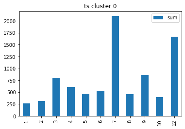

```python
interaction_dict_t0['0'].plot.bar(y='sum', use_index=True, title = x+' cluster 0')
```

```python
def barPlots(interaction_dict_t = {}, timepoint = ''):
    '''
    Generates a bar plot for each cluster df in the interaction dict.
    The higher the bar the more C-C interaction between the two clusters (one in title and the one on x-axis whos bar is high) based on LxR interaction score.
    '''
    for key in interaction_dict_t:
        interaction_dict_t[key].plot.bar(y='sum', use_index=True, title = 'Timepoint: ' + timepoint + ' , Cluster: ' + key)
```

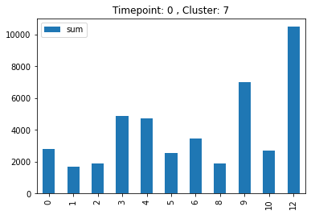

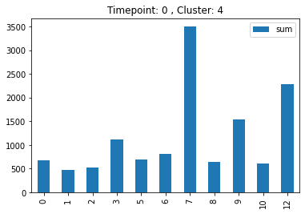

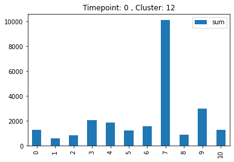

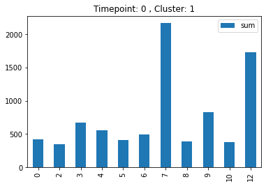

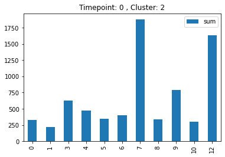

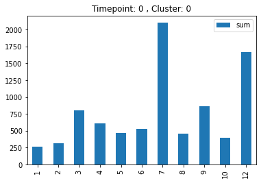

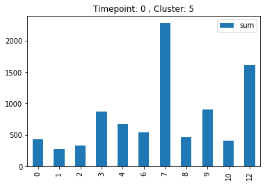

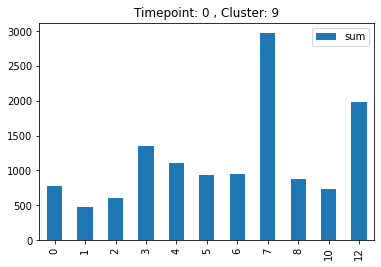

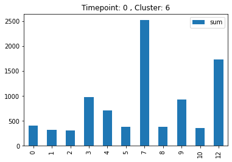

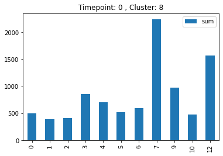

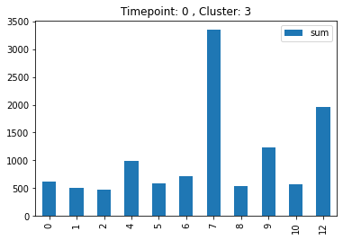

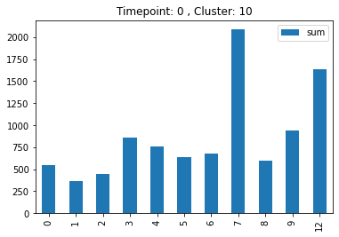

```python
barPlots(interaction_dict_t0, '0')
```

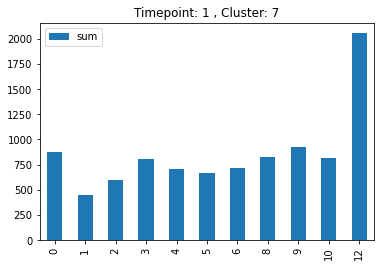

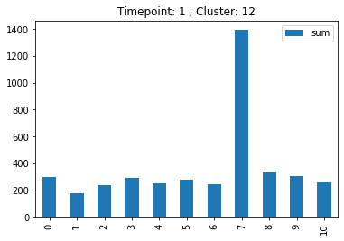

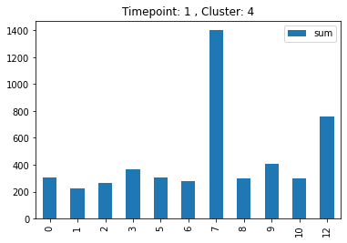

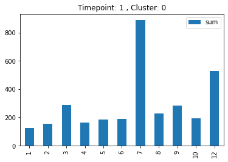

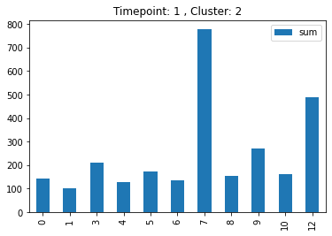

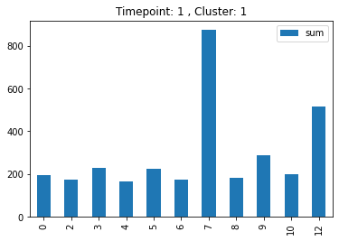

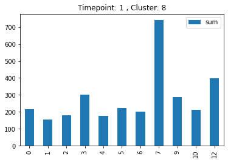

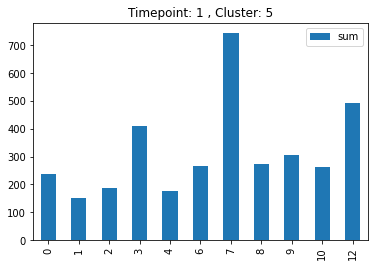

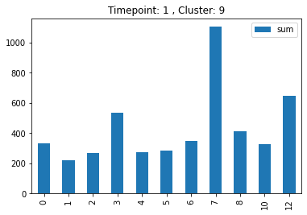

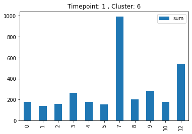

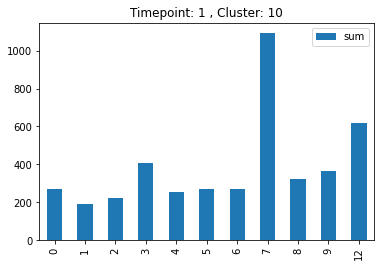

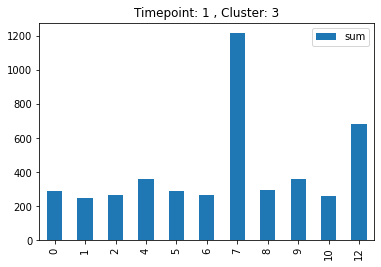

```python
barPlots(interaction_dict_t1, '1')
```